# Homework 5

Arden Moser

2026-01-20

Personal Note: ALWAYS USE PIPES (%>%) for clarity

## Instructions

Answer the following questions and/or complete the exercises in RMarkdown. Please embed all of your code and push the final work to your repository. Your report should be organized, clean, and run free from errors. Remember, you must remove the `#` for any included code chunks to run. Any plots must have appropriate titles and aesthetics.

## Load the tidyverse

```r
library("tidyverse")
options(scipen=999) #turn off scientific notation
```

## Data

**Database of vertebrate home range sizes.** Reference: Tamburello N, Cote IM, Dulvy NK (2015) Energy and the scaling of animal space use. The American Naturalist 186(2):196-211. http://dx.doi.org/10.1086/682070.  
Data: http://datadryad.org/resource/doi:10.5061/dryad.q5j65/1

**1. Load the data into a new object called `homerange`.**

```r
homerange <- read.csv("data/Tamburelloetal_HomeRangeDatabase.csv")
```

**2. What is the structure of the `homerange` data? Does it have any NA’s? Do a quick exploratory analysis of your choice below.**

```r
summary(homerange)
```

```
##     taxon           common.name           class              order
##  Length:569         Length:569         Length:569         Length:569
##  Class :character   Class :character   Class :character   Class :character
##  Mode  :character   Mode  :character   Mode  :character   Mode  :character
##
##
##
##
##     family             genus             species          primarymethod
##  Length:569         Length:569         Length:569         Length:569
##  Class :character   Class :character   Class :character   Class :character
##  Mode  :character   Mode  :character   Mode  :character   Mode  :character
##
##
##
##
##       N              mean.mass.g          log10.mass
##  Length:569         Min.   :      0.2   Min.   :-0.6576
##  Class :character   1st Qu.:     50.0   1st Qu.: 1.6990
##  Mode  :character   Median :    330.0   Median : 2.5185
##                     Mean   :  34602.0   Mean   : 2.5947
##                     3rd Qu.:   2150.0   3rd Qu.: 3.3324
##                     Max.   :4000000.1   Max.   : 6.6021
##
##  alternative.mass.reference  mean.hra.m2           log10.hra
##  Length:569                 Min.   :         0   Min.   :-1.523
##  Class :character           1st Qu.:      4500   1st Qu.: 3.653
##  Mode  :character           Median :     39344   Median : 4.595
##                             Mean   :  21456509   Mean   : 4.709
##                             3rd Qu.:   1038100   3rd Qu.: 6.016
##                             Max.   :3550830977   Max.   : 9.550
##
##  hra.reference         realm           thermoregulation    locomotion
##  Length:569         Length:569         Length:569         Length:569
##  Class :character   Class :character   Class :character   Class :character
##  Mode  :character   Mode  :character   Mode  :character   Mode  :character
##
##
##
##
##  trophic.guild       dimension            preymass         log10.preymass
##  Length:569         Length:569         Min.   :     0.67   Min.   :-0.1739
##  Class :character   Class :character   1st Qu.:    20.02   1st Qu.: 1.3014
##  Mode  :character   Mode  :character   Median :    53.75   Median : 1.7304
##                                        Mean   :  3989.88   Mean   : 2.0188
##                                        3rd Qu.:   363.35   3rd Qu.: 2.5603
##                                        Max.   :130233.20   Max.   : 5.1147
##                                        NA's   :502         NA's   :502
##       PPMR         prey.size.reference
##  Min.   :  0.380   Length:569
##  1st Qu.:  3.315   Class :character
##  Median :  7.190   Mode  :character
##  Mean   : 31.752
##  3rd Qu.: 15.966
##  Max.   :530.000
##  NA's   :502
```

```r
glimpse(homerange)
```

```
## Rows: 569
## Columns: 24
## $ taxon                      <chr> "lake fishes", "river fishes", "river fishe…
## $ common.name                <chr> "american eel", "blacktail redhorse", "cent…
## $ class                      <chr> "actinopterygii", "actinopterygii", "actino…
## $ order                      <chr> "anguilliformes", "cypriniformes", "cyprini…
## $ family                     <chr> "anguillidae", "catostomidae", "cyprinidae"…
## $ genus                      <chr> "anguilla", "moxostoma", "campostoma", "cli…
## $ species                    <chr> "rostrata", "poecilura", "anomalum", "fundu…
## $ primarymethod              <chr> "telemetry", "mark-recapture", "mark-recapt…
## $ N                          <chr> "16", NA, "20", "26", "17", "5", "2", "2", …
## $ mean.mass.g                <dbl> 887.00, 562.00, 34.00, 4.00, 4.00, 3525.00,…
## $ log10.mass                 <dbl> 2.9479236, 2.7497363, 1.5314789, 0.6020600,…
## $ alternative.mass.reference <chr> NA, NA, NA, NA, NA, NA, NA, NA, NA, NA, NA,…
## $ mean.hra.m2                <dbl> 282750.00, 282.10, 116.11, 125.50, 87.10, 3…
## $ log10.hra                  <dbl> 5.4514026, 2.4504031, 2.0648696, 2.0986437,…
## $ hra.reference              <chr> "Minns, C. K. 1995. Allometry of home range…
## $ realm                      <chr> "aquatic", "aquatic", "aquatic", "aquatic",…
## $ thermoregulation           <chr> "ectotherm", "ectotherm", "ectotherm", "ect…
## $ locomotion                 <chr> "swimming", "swimming", "swimming", "swimmi…
## $ trophic.guild              <chr> "carnivore", "carnivore", "carnivore", "car…
## $ dimension                  <chr> "3D", "2D", "2D", "2D", "2D", "2D", "2D", "…
## $ preymass                   <dbl> NA, NA, NA, NA, NA, NA, 1.39, NA, NA, NA, N…
## $ log10.preymass             <dbl> NA, NA, NA, NA, NA, NA, 0.1430148, NA, NA, …
## $ PPMR                       <dbl> NA, NA, NA, NA, NA, NA, 530, NA, NA, NA, NA…
## $ prey.size.reference        <chr> NA, NA, NA, NA, NA, NA, "Brose U, et al. 20…
```

```r
names(homerange)
```

```
##  [1] "taxon"                      "common.name"
##  [3] "class"                      "order"
##  [5] "family"                     "genus"
##  [7] "species"                    "primarymethod"
##  [9] "N"                          "mean.mass.g"
## [11] "log10.mass"                 "alternative.mass.reference"
## [13] "mean.hra.m2"                "log10.hra"
## [15] "hra.reference"              "realm"
## [17] "thermoregulation"           "locomotion"
## [19] "trophic.guild"              "dimension"
## [21] "preymass"                   "log10.preymass"
## [23] "PPMR"                       "prey.size.reference"
```

The “homerange” dataframe is a structured table with 569 rows and 24 columns labeled with the following variables: taxon, common.name, class, order, family, genus, species, primarymethod, N, mean.mass.g, log10.mass, alternative.mass.reference, mean.hra.m2, log10.hra, hra.reference, realm, thermoregulation, locomotion, trophic.guild, dimension, preymass, log10.preymass, PPMR, and prey.size.reference. Its variables contain string and numeric data but several cells have NA. The biggest offenders are “preymass”, “log10.preymass”, and “PPMR” with have over 500 NA’s each.

**3. Which animal groups are represented in the data? Make a plot that shows the number in each class.**

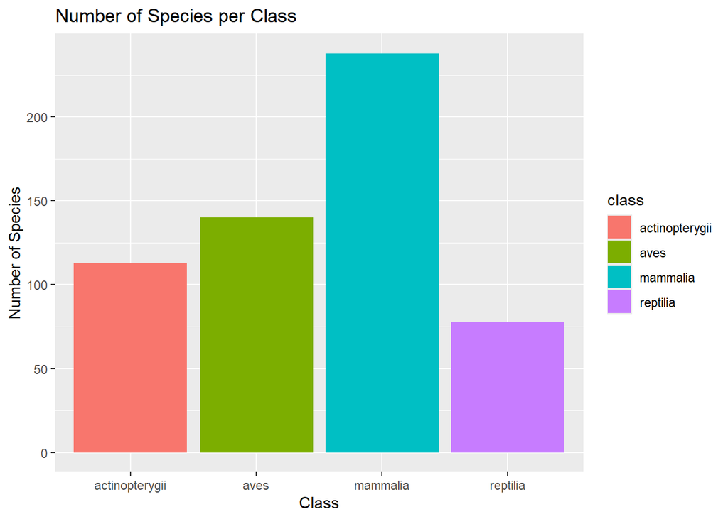

```r
ggplot(data = homerange, aes(x = class, fill = class)) +
  geom_bar() +
  labs(
    title = "Number of Species per Class",
    x = "Class",
    y = "Number of Species"
  )
```

Actinopterygii, aves, mammalia, and reptilia are represented in the data

**4. Are there more carnivores or herbivores represented in the data? Make a plot that shows the number in each trophic guild.**

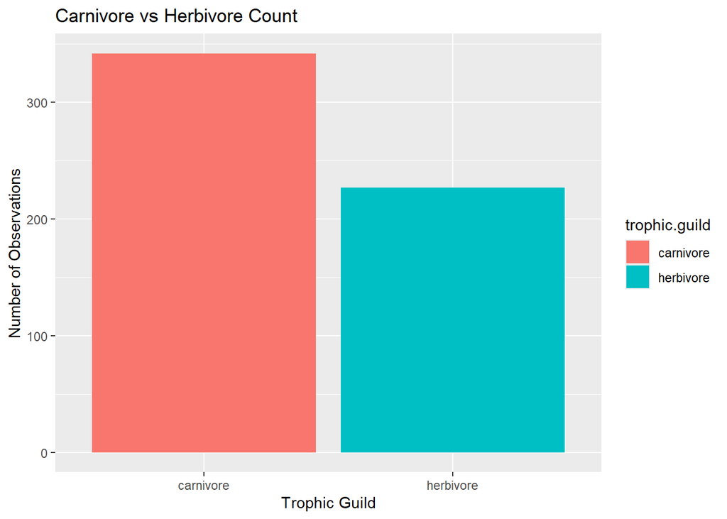

```r
ggplot(data = homerange %>% filter(trophic.guild=="carnivore" | trophic.guild=="herbivore"), aes(x = trophic.guild, fill = trophic.guild)) +
  geom_bar() +
  labs(
    title = "Carnivore vs Herbivore Count",
    x = "Trophic Guild",
    y = "Number of Observations"
  )
```

There are more carnivores represented in the data.

**5. Which herbivorous mammals have homeranges greater than 1,000,000 m²? Show only the common name, order, mean homerange size, and mean body mass. Arrange the data in descending order by homerange size and show only the top 10 species.**

```r
homerange %>%
  select(common.name, order, mean.hra.m2, mean.mass.g, trophic.guild, taxon) %>%
  filter(trophic.guild=="herbivore" & taxon=="mammals") %>%
  select(common.name, order, mean.hra.m2, mean.mass.g) %>%
  arrange(desc(mean.hra.m2)) %>%
  filter(mean.hra.m2>=52399844.72)
```

```
##              common.name        order mean.hra.m2 mean.mass.g
## 1               reindeer artiodactyla  3550830977   102058.69
## 2  African bush elephant  proboscidea  1753759352  4000000.08
## 3           greater kudu artiodactyla  1070039969   197314.95
## 4         American bison artiodactyla   265778594   629999.20
## 5                giraffe artiodactyla   136536888  1339985.19
## 6         Asian elephant  proboscidea   109999320  4000000.08
## 7                  moose artiodactyla    93825308   307227.44
## 8               red deer artiodactyla    74865202   234757.78
## 9                   goat artiodactyla    64528267    50999.98
## 10          common eland artiodactyla    52399845   635038.42
```

Reindeer, African Bush Elephants, Greater Kudu, American Bison, Giraffes, Asian Elephants, Moose, Red Deer, Goats and Common Elands are the top ten herbivious mammals that have homeranges greater then 1,000,000 m².

**6. Which two species have the largest and smallest homerange sizes?**

```r
homerange %>%
  select(common.name,mean.hra.m2) %>%
  arrange(desc(mean.hra.m2)) %>%
  filter(common.name=="reindeer" | common.name=="rusty goby")
```

```
##   common.name   mean.hra.m2
## 1    reindeer 3550830977.00
## 2  rusty goby          0.03
```

Reindeer have the largest homerange sizes. Rusty Gobies have the smallest homerange.

**7. Which carnivorous mammals have the largest homeranges?**

```r
homerange %>%
  select(common.name, mean.hra.m2, trophic.guild, taxon) %>%
  filter(trophic.guild=="carnivore" & taxon=="mammals") %>%
  select(common.name, mean.hra.m2) %>%
  arrange(desc(mean.hra.m2))
```

```
##                       common.name  mean.hra.m2
## 1                         cheetah 815060787.90
## 2                         leopard 504940260.80
## 3                         caracal 376634414.00
## 4                       wolverine 361917847.30
## 5                          cougar 312003883.70
## 6                   Eurasian lynx 181042275.70
## 7                     Canada lynx  82748475.24
## 8                          jaguar  82735138.83
## 9                      jaguarundi  67079528.30
## 10                          tiger  53583367.03
## 11                         bobcat  39877690.65
## 12                   Ruppel's fox  30399749.15
## 13                     arctic fox  28499024.85
## 14                   snow leopard  17353217.10
```

[output cut: 66 more lines]

Cheetahs, leopards, caracal, wolverines, cougars, Euresian lynx, Canada lynx, Jaguars, Jaguarundi, and Tigers are the top ten carnivorious mammals with the largest homeranges.

**8. Is there a relationship between body mass and homerange size? Make a scatterplot to show this relationship. Be sure to include appropriate labels and a title.**

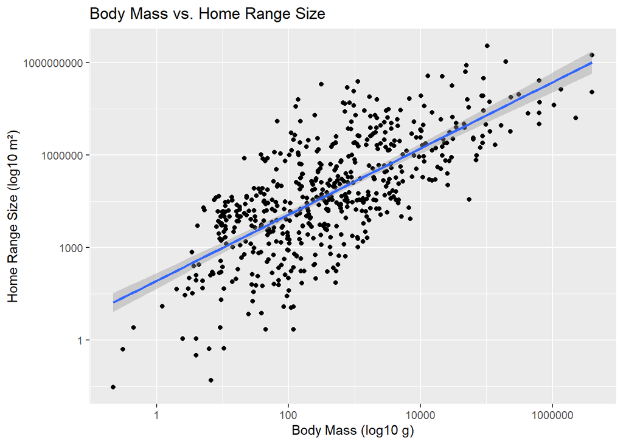

```r
ggplot(data = homerange, aes(x = mean.mass.g, y = mean.hra.m2)) +
  scale_x_log10() +
  scale_y_log10() +
  geom_point() +
  geom_smooth(method = lm) +
  labs(
    title = "Body Mass vs. Home Range Size",
    x = "Body Mass (log10 g)",
    y = "Home Range Size (log10 m²)"
  )
```

There seems to be a generally linear, positive relationship between body mass and home range sizes.

**9. Use filter to extract the data for only birds and mammals. Then make a plot that compares the homerange sizes of these two groups. Be sure to include appropriate labels and a title.**

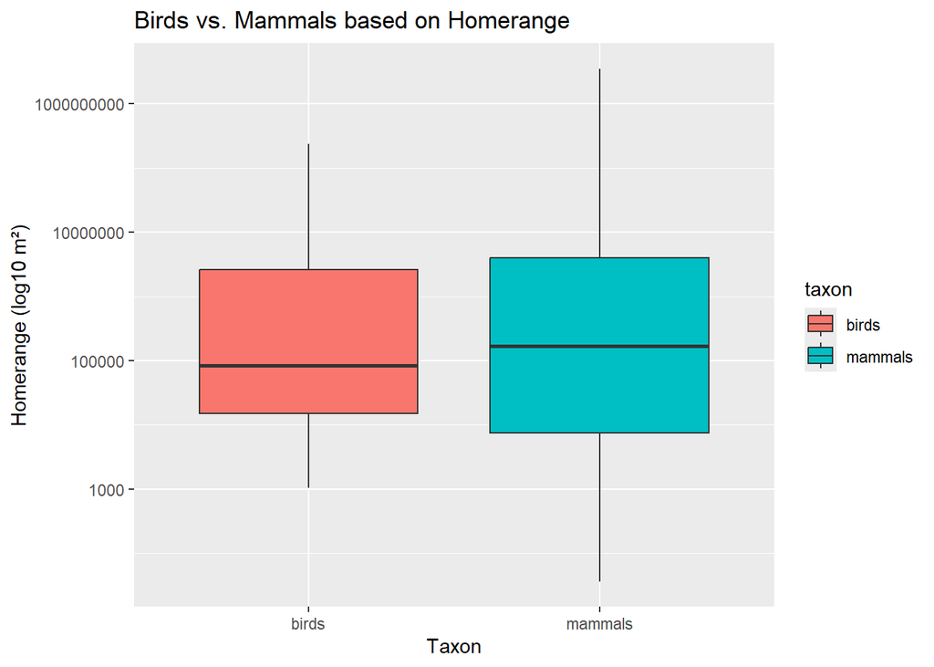

```r
ggplot(data = homerange %>%
         filter(taxon == "birds" | taxon == "mammals"),
       aes(x = taxon, y = mean.hra.m2, fill = taxon)) +
  scale_y_log10() +
  geom_boxplot() +
  labs(
    title = "Birds vs. Mammals based on Homerange",
    x = "Taxon",
    y = "Homerange (log10 m²)"
  )
```

**10. Do one additional exploratory analysis of your choice. Before writing the code, write the question you are trying to answer. The question should be biologically meaningful and appropriate for the data. It must include at least one `filter()`, `select()`, and `arrange()`.**

```r
top10_homerange <- homerange %>%
  select(taxon, common.name, mean.hra.m2) %>%
  filter(taxon=="marine fishes") %>%
  select(common.name, mean.hra.m2) %>%
  arrange(desc(mean.hra.m2)) %>%
  filter(mean.hra.m2>=52773.00)
top10_bodymass <- homerange %>%
  select(taxon, common.name, mean.mass.g) %>%
  filter(taxon=="marine fishes") %>%
  select(common.name, mean.mass.g) %>%
  arrange(desc(mean.mass.g)) %>%
  filter(mean.mass.g>=1644.90)
intersect(top10_homerange$common.name, top10_bodymass$common.name)
```

```
## [1] "mutton snapper" "red grouper"    "black grouper"  "greasy grouper"
## [5] "coral grouper"
```

Research Question: How much overlap exists between the top ten marine fish species by home range size and the top ten by body mass?”

Conclusion: Only five of the top ten marine fish species ranked by home range overlap with the top ten ranked by body mass. These species are the mutton snapper, red grouper, black grouper, greasy grouper, and coral grouper. This partial overlap suggests that body mass alone does not fully explain the variation in home range among marine fish species.

## Knit and Upload

Please knit your work as an .html file and upload to Canvas. Homework is due before the start of the next lab. No late work is accepted. Make sure to use the formatting conventions of RMarkdown to make your report neat and clean!